# PMLProject

Louis Conserve

11/12/2016

## Introduction

Using devices such as Jawbone Up, Nike FuelBand, and Fitbit it is now possible to collect a large amount of data about personal activity relatively inexpensively. These type of devices are part of the quantified self movement – a group of enthusiasts who take measurements about themselves regularly to improve their health, to find patterns in their behavior, or because they are tech geeks. One thing that people regularly do is quantify how much of a particular activity they do, but they rarely quantify how well they do it. In this project, your goal will be to use data from accelerometers on the belt, forearm, arm, and dumbell of 6 participants. They were asked to perform barbell lifts correctly and incorrectly in 5 different ways.

## Project Data

The data for this project come from this source: http://groupware.les.inf.puc-rio.br/har. If you use the document you create for this class for any purpose please cite them as they have been very generous in allowing their data to be used for this kind of assignment.

The training data for this project are available here: https://d396qusza40orc.cloudfront.net/predmachlearn/pml-training.csv

The test data are available here: https://d396qusza40orc.cloudfront.net/predmachlearn/pml-testing.csv

## Objective

The goal of your project is to predict the manner in which they did the exercise. This is the “classe” variable in the training set. You may use any of the other variables to predict with. You should create a report describing how you built your model, how you used cross validation, what you think the expected out of sample error is, and why you made the choices you did. You will also use your prediction model to predict 20 different test cases.

## Getting Started

Loading necessary libraries

library(caret)  
library(rpart)  
library(rpart.plot)  
library(RColorBrewer)  
library(rattle)  
library(randomForest)  
library(knitr)

### Prepare the datasets

```r
set.seed(12345)
# Getting the training and test data from source
trainingdataUrl <- "http://d396qusza40orc.cloudfront.net/predmachlearn/pml-training.csv"
testingdataUrl <- "http://d396qusza40orc.cloudfront.net/predmachlearn/pml-testing.csv"
#Reading the training and test data
training <- read.csv(url(trainingdataUrl), na.strings=c("NA","#DIV/0!",""))
testing <- read.csv(url(testingdataUrl), na.strings=c("NA","#DIV/0!",""))
```

### The training data split in two for training set and testing set

```r
split <- createDataPartition(training$classe, p=0.6, list=FALSE)
trainingSet <- training[split, ] # Create a training set
testSet <- training[-split, ] #Create a testing set from the training data
dim(trainingSet)
```

```
## [1] 11776   160
```

```r
dim(testSet)
```

```
## [1] 7846  160
```

## Cleaning the datasets

Removing the variables that are very close to zero

```r
#from training set
nzv <- nearZeroVar(trainingSet, saveMetrics=TRUE)
trainingSet <- trainingSet[,nzv$nzv==FALSE]
#from testing set
nzv<- nearZeroVar(testSet,saveMetrics=TRUE)
testSet <- testSet[,nzv$nzv==FALSE]
#Removing the first column trainingSet dataset
trainingSet <- trainingSet[c(-1)]
```

Cleanning records with more than 70% NA

```r
trainingSubset <- trainingSet
for(i in 1:length(trainingSet))
  {if( sum( is.na( trainingSet[, i] ) ) /nrow(trainingSet) >= .7)
    {for(j in 1:length(trainingSubset))
      {if( length( grep(names(trainingSet[i]), names(trainingSubset)[j]) ) == 1)
        {trainingSubset <- trainingSubset[ , -j]
        }
      }
    }
 }
trainingSet <- trainingSubset
rm(trainingSubset)
```

Transforming the testSet and testing datasets

```r
transformA <- colnames(trainingSet)
transformB <- colnames(trainingSet[, -58])  # remove the classe column
testSet <- testSet[transformA]  #Only variables in testSet AND in trainingSet are kept
testing <- testing[transformB]  #Only variables in testing AND in trainingSet are kept
dim(testSet)
```

```
## [1] 7846   58
```

```r
dim(testing)
```

```
## [1] 20 57
```

Transforming the testing data into the same type

```r
for (i in 1:length(testing) )
  {for(j in 1:length(trainingSet))
      { if( length( grep(names(trainingSet[i]), names(testing)[j]) ) == 1)
          {class(testing[j]) <- class(trainingSet[i])
          }
       }
    }
# Getting the same class for testing and trainingSet
testing <- rbind(trainingSet[2, -58] , testing)
testing <- testing[-1,]
```

### Model Building

##### Decision Trees Prediction (model A)

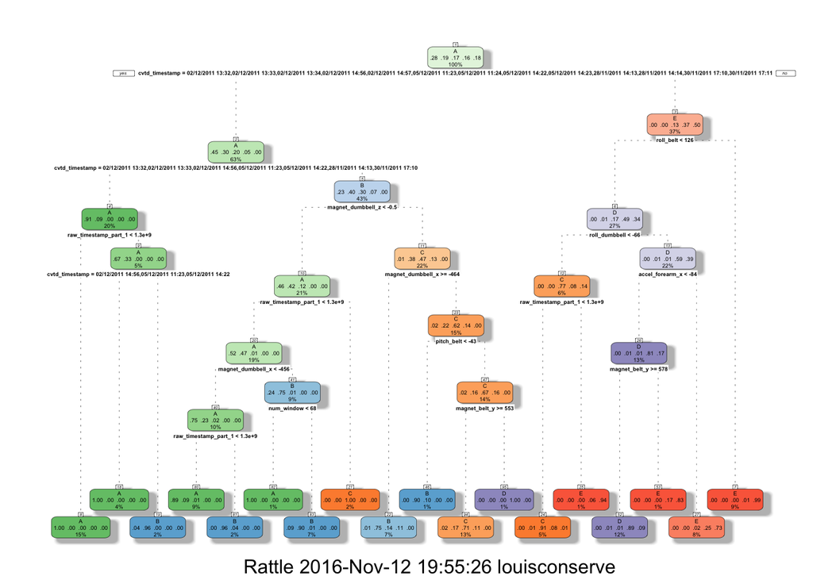

```r
set.seed(777)
#First Model(A)
modelA <- rpart(classe ~ ., data=trainingSet, method="class")
fancyRpartPlot(modelA)
```

Evaluating the training prediction with the testing set (model A)

```r
predictModelA <- predict(modelA, testSet, type = "class")
cmtree <- confusionMatrix(predictModelA, testSet$classe)
cmtree
```

```
## $positive
## NULL
##
## $table
##           Reference
## Prediction    A    B    C    D    E
##          A 2150   60    7    1    0
##          B   61 1260   69   64    0
##          C   21  188 1269  143    4
##          D    0   10   14  857   78
##          E    0    0    9  221 1360
##
## $overall
##       Accuracy          Kappa  AccuracyLower  AccuracyUpper   AccuracyNull
##      0.8789192      0.8467985      0.8714961      0.8860595      0.2844762
## AccuracyPValue  McnemarPValue
##      0.0000000            NaN
##
## $byClass
##          Sensitivity Specificity Pos Pred Value Neg Pred Value Precision
## Class: A   0.9632616   0.9878874      0.9693417      0.9854300 0.9693417
## Class: B   0.8300395   0.9693426      0.8665750      0.9596370 0.8665750
## Class: C   0.9276316   0.9450448      0.7809231      0.9840862 0.7809231
## Class: D   0.6664075   0.9844512      0.8936392      0.9377087 0.8936392
## Class: E   0.9431345   0.9640849      0.8553459      0.9868926 0.8553459
##             Recall        F1 Prevalence Detection Rate
## Class: A 0.9632616 0.9662921  0.2844762      0.2740250
## Class: B 0.8300395 0.8479139  0.1934744      0.1605914
## Class: C 0.9276316 0.8479786  0.1743564      0.1617385
## Class: D 0.6664075 0.7634744  0.1639052      0.1092276
## Class: E 0.9431345 0.8970976  0.1837879      0.1733367
##          Detection Prevalence Balanced Accuracy
## Class: A            0.2826918         0.9755745
## Class: B            0.1853174         0.8996911
## Class: C            0.2071119         0.9363382
## Class: D            0.1222279         0.8254293
## Class: E            0.2026510         0.9536097
##
## $mode
## [1] "sens_spec"
##
## $dots
## list()
##
## attr(,"class")
## [1] "confusionMatrix"
```

##### Random Forests Prediction (Model B)

```r
set.seed(777)
#second Model(B)
ModelB <- randomForest(classe ~ ., data=trainingSet)
```

Evaluate my training prediction with the testing set (Model B)

```r
predictModelB <- predict(ModelB, testSet, type = "class")
cmrf <- confusionMatrix(predictModelB, testSet$classe)
cmrf
```

```
## $positive
## NULL
##
## $table
##           Reference
## Prediction    A    B    C    D    E
##          A 2231    2    0    0    0
##          B    1 1516    1    0    0
##          C    0    0 1366    3    0
##          D    0    0    1 1282    0
##          E    0    0    0    1 1442
##
## $overall
##       Accuracy          Kappa  AccuracyLower  AccuracyUpper   AccuracyNull
##      0.9988529      0.9985491      0.9978236      0.9994754      0.2844762
## AccuracyPValue  McnemarPValue
##      0.0000000            NaN
##
## $byClass
##          Sensitivity Specificity Pos Pred Value Neg Pred Value Precision
## Class: A   0.9995520   0.9996437      0.9991043      0.9998218 0.9991043
## Class: B   0.9986825   0.9996839      0.9986825      0.9996839 0.9986825
## Class: C   0.9985380   0.9995369      0.9978086      0.9996912 0.9978086
## Class: D   0.9968896   0.9998476      0.9992206      0.9993905 0.9992206
## Class: E   1.0000000   0.9998438      0.9993070      1.0000000 0.9993070
##             Recall        F1 Prevalence Detection Rate
## Class: A 0.9995520 0.9993281  0.2844762      0.2843487
## Class: B 0.9986825 0.9986825  0.1934744      0.1932195
## Class: C 0.9985380 0.9981732  0.1743564      0.1741015
## Class: D 0.9968896 0.9980537  0.1639052      0.1633954
## Class: E 1.0000000 0.9996534  0.1837879      0.1837879
##          Detection Prevalence Balanced Accuracy
## Class: A            0.2846036         0.9995979
## Class: B            0.1934744         0.9991832
## Class: C            0.1744838         0.9990375
## Class: D            0.1635228         0.9983686
## Class: E            0.1839154         0.9999219
##
## $mode
## [1] "sens_spec"
##
## $dots
## list()
##
## attr(,"class")
## [1] "confusionMatrix"
```

##### Generalized Boosted Regression Prediction (Model C)

```r
set.seed(777)
fitControl <- trainControl(method = "repeatedcv",number = 5,repeats = 1)
gmbModelC <- train(classe ~ ., data=trainingSet, method = "gbm",trControl = fitControl,verbose = FALSE)
gbmFinMod1 <- gmbModelC$finalModel
gbmPredTest <- predict(gmbModelC, newdata=testSet)
gbmAccuracyTest <- confusionMatrix(gbmPredTest, testSet$classe)
gbmAccuracyTest
```

```
## $positive
## NULL
##
## $table
##           Reference
## Prediction    A    B    C    D    E
##          A 2232    5    0    0    0
##          B    0 1510    0    0    0
##          C    0    2 1360    6    0
##          D    0    1    8 1271    1
##          E    0    0    0    9 1441
##
## $overall
##       Accuracy          Kappa  AccuracyLower  AccuracyUpper   AccuracyNull
##      0.9959215      0.9948408      0.9942472      0.9972087      0.2844762
## AccuracyPValue  McnemarPValue
##      0.0000000            NaN
##
## $byClass
##          Sensitivity Specificity Pos Pred Value Neg Pred Value Precision
## Class: A   1.0000000   0.9991094      0.9977649      1.0000000 0.9977649
## Class: B   0.9947299   1.0000000      1.0000000      0.9987374 1.0000000
## Class: C   0.9941520   0.9987651      0.9941520      0.9987651 0.9941520
## Class: D   0.9883359   0.9984756      0.9921936      0.9977152 0.9921936
## Class: E   0.9993065   0.9985946      0.9937931      0.9998437 0.9937931
##             Recall        F1 Prevalence Detection Rate
## Class: A 1.0000000 0.9988812  0.2844762      0.2844762
## Class: B 0.9947299 0.9973580  0.1934744      0.1924548
## Class: C 0.9941520 0.9941520  0.1743564      0.1733367
## Class: D 0.9883359 0.9902610  0.1639052      0.1619934
## Class: E 0.9993065 0.9965422  0.1837879      0.1836605
##          Detection Prevalence Balanced Accuracy
## Class: A            0.2851134         0.9995547
## Class: B            0.1924548         0.9973650
## Class: C            0.1743564         0.9964585
## Class: D            0.1632679         0.9934058
## Class: E            0.1848075         0.9989506
##
## $mode
## [1] "sens_spec"
##
## $dots
## list()
##
## attr(,"class")
## [1] "confusionMatrix"
```

## Evaluate Data Result prediction

We got 87.89% acuracy from ModelA (Decision Trees Prediction);

We got 99.89% acuracy from ModelB (Random Forests Prediction);

and we got 99.59 acuracy from Model C (Generalized Boosted Regression Prediction);

We are chosing the most accurate model (ModelB) for the final prediction (testing data). We are expecting on getting 0.11% (100%-99.89%) out of sample error.

```r
predictModelB <- predict(ModelB, testing, type = "class")
predictModelB
```

```
##  2 31  4  5  6  7  8  9 10 11 12 13 14 15 16 17 18 19 20 21
##  B  A  B  A  A  E  D  B  A  A  B  C  B  A  E  E  A  B  B  B
## Levels: A B C D E
```

```r
# Write the results to a text file for submission
pml_write_files = function(x)
  {n = length(x)
   # path <- "/Users/louisconserve/Desktop/Coursera" # given path
    for(i in 1:n)
      {filename = paste0("problem_id_",i,".txt")
        write.table(x[i],file=filename,quote=FALSE,row.names=FALSE,col.names=FALSE)
      }
   }
#pml_write_files (predictModelB) #export files to given path
```

Thanks to Stackoverflow Community and Danny